# Assignment 3 - CRD

Author

COMFORT ADEGBENRO

# Introduction

This assignment will ask you to conduct a full CRD analysis, from data import through publication ready plot.

For that, you will first need to watch (and code along with) the following CRD videos:

- CRD lecture: https://youtu.be/r5vsakgqMXc?si=8udshzlpZ-8td1f4&t=4941 (starts at 1:22:21, watch till end)
- CRD lecture pt 2, lab pt 1: https://youtu.be/GpfHxh1eK5U?si=nTle5YcB8JQklja2 (watch whole video)
- CRD lab pt 2: https://youtu.be/YQ1bK6uV194?si=LnDzRT69OsiMLc-r (wathc the whole video)

**AFTER watching the videos and developing the code in class**, then start working on this HW assignment.

The different sections representing what we did in class were left in the script to provide you a scaffold to start from.

# Instructions

- Move this script into the `code` subfolder of your `03_crd` project folder
- Move the file `wheat_nk_bamyan.csv` into the `data` folder of your `03_crd` project folder
- On this script, fill your name under the `title` section of the YAML

# a) Setup

Here is where we load the packages we will use.  
Make sure to load each package in the chunk below.

```r
# Loading packages
library(tidyverse)
library(car)
library(broom)
library(emmeans)
library(multcomp)
library(lmtest)
```

Now, import the data set `wheat_nk_bamyan.csv` in the chunk below.

```r
crd_ass = read_csv("../data/wheat_nk_bamyan.csv")
head(crd_ass, 3)
```

```
# A tibble: 3 × 5
    trt   rep nrate_kgha krate_kgha yield_kgha
  <dbl> <dbl>      <dbl>      <dbl>      <dbl>
1     1     1          0          0       1350
2     2     1          0         30       2110
3     3     1          0         60       5725
```

The **objective of this study** was to assess the effect of different N and K rates on wheat yield.

For that, a study was conducted using a completely randomized design as the experimental design with four replicates. The treatment design was a 3 N x 3 K rate factorial, for a total of 9 treatments.

# b) EDA tables

Use this space to conduct exploratory data analysis of the imported data, in the form of tables.

```r
summary(crd_ass)
```

```
      trt         rep         nrate_kgha    krate_kgha   yield_kgha
 Min.   :1   Min.   :1.00   Min.   :  0   Min.   : 0   Min.   : 812
 1st Qu.:3   1st Qu.:1.75   1st Qu.:  0   1st Qu.: 0   1st Qu.:2630
 Median :5   Median :2.50   Median :100   Median :30   Median :3750
 Mean   :5   Mean   :2.50   Mean   :100   Mean   :30   Mean   :3838
 3rd Qu.:7   3rd Qu.:3.25   3rd Qu.:200   3rd Qu.:60   3rd Qu.:5238
 Max.   :9   Max.   :4.00   Max.   :200   Max.   :60   Max.   :7232
```

```r
glimpse(crd_ass)
```

```
Rows: 36
Columns: 5
$ trt        <dbl> 1, 2, 3, 4, 5, 6, 7, 8, 9, 1, 2, 3, 4, 5, 6, 7, 8, 9, 1, 2,…
$ rep        <dbl> 1, 1, 1, 1, 1, 1, 1, 1, 1, 2, 2, 2, 2, 2, 2, 2, 2, 2, 3, 3,…
$ nrate_kgha <dbl> 0, 0, 0, 100, 100, 100, 200, 200, 200, 0, 0, 0, 100, 100, 1…
$ krate_kgha <dbl> 0, 30, 60, 0, 30, 60, 0, 30, 60, 0, 30, 60, 0, 30, 60, 0, 3…
$ yield_kgha <dbl> 1350, 2110, 5725, 2988, 3438, 6525, 2825, 4400, 7025, 2250,…
```

# c) Wrangling

Here, make sure to wrangle your data set with all needed steps. Refer back to class code if you need a refresher on what was needed.

```r
crd_asw = crd_ass %>%
  mutate(rep = factor(rep),
         nrate_kgha = factor(nrate_kgha),
         krate_kgha = factor(krate_kgha) # change the structure from dbl to factor
         ) %>%
  mutate(trtname = paste0(nrate_kgha,"+",krate_kgha)) # add a new column for treatment combination

head(crd_asw, 3)
```

```
# A tibble: 3 × 6
    trt rep   nrate_kgha krate_kgha yield_kgha trtname
  <dbl> <fct> <fct>      <fct>           <dbl> <chr>
1     1 1     0          0                1350 0+0
2     2 1     0          30               2110 0+30
3     3 1     0          60               5725 0+60
```

```r
summary(crd_asw) # check summary of data again to confirm changes
```

```
      trt    rep   nrate_kgha krate_kgha   yield_kgha     trtname
 Min.   :1   1:9   0  :12     0 :12      Min.   : 812   Length:36
 1st Qu.:3   2:9   100:12     30:12      1st Qu.:2630   Class :character
 Median :5   3:9   200:12     60:12      Median :3750   Mode  :character
 Mean   :5   4:9                         Mean   :3838
 3rd Qu.:7                               3rd Qu.:5238
 Max.   :9                               Max.   :7232
```

## Question 1) Below each plot of this section, write a sentence explaining your visual interpretation of the plot.

# d) EDA plots

Now, explore the wrangled data using plots.  
Make sure to explore plots showing the main effects and the interaction.

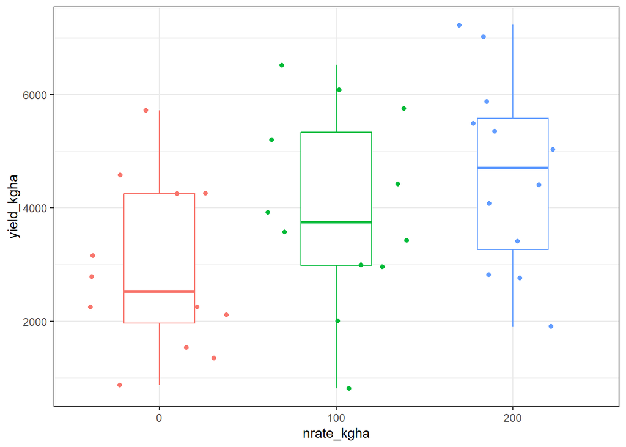

```r
ggplot(crd_asw, aes(x= nrate_kgha,
                    y= yield_kgha,
                    color= nrate_kgha
                    )) +
  geom_boxplot(width= 0.4) +
  geom_jitter() +
  theme_bw() +
  theme(legend.position = "none") # box plot to understand nitrogen effects on yield
```

The box plot showing the effect of nitrogen rates on the yield of wheat suggests that there could be nitrogen effect on yield. Specifically, the 200 kg/ha rate of nitrogen gives higher wheat yield, with the 0 kg/ha nitrogen rate having the lowest wheat yield.

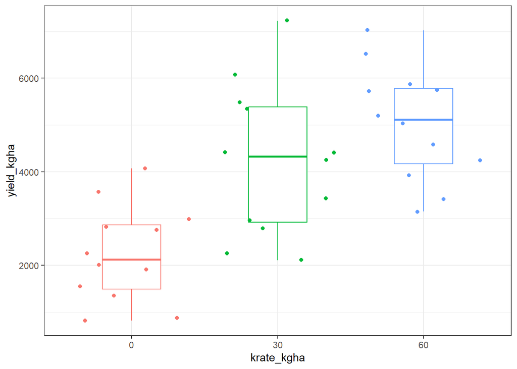

```r
ggplot(crd_asw, aes(x= krate_kgha,
                    y= yield_kgha,
                    color= krate_kgha
                    )) +
  geom_boxplot(width = 0.4) +
  geom_jitter() +
  theme_bw() +
  theme(legend.position = "none") # quick overview of potassium effect on wheat yield
```

Similar to the effect of nitrogen, the highest potassium rate (60 kg/ha) seems to support more yield compared to the other rates. The 0 kg/ha of potassium resulted in the lowest yield.

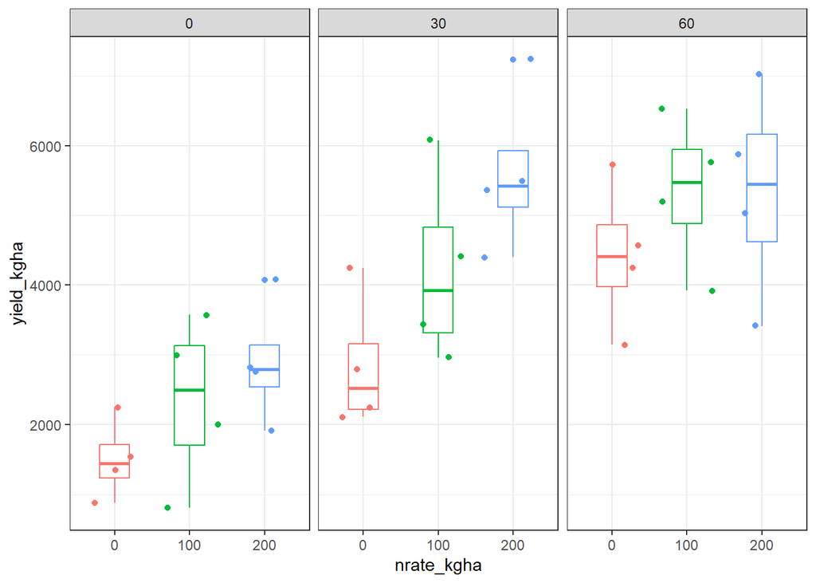

```r
ggplot(crd_asw, aes(x= nrate_kgha,
                    y= yield_kgha,
                    color= nrate_kgha
                    )) +
  geom_boxplot(width = 0.4) +
  geom_jitter() +
  facet_grid(.~krate_kgha) +
  theme_bw() +
  theme(legend.position = "none") # nitrogen and potassium interaction
```

The box plot for the nitrogen by potassium shows possible interactions. For instance, as potassium rates increased from 0 to 30 to 60 kg/ha, the yield increased irrespective of the nitrogen rate. Additionally, when potassium increased from 0 to 30 kg/ha, the yield responses for the nitrogen treatments was clearly different, with the 200 kg/ha of nitrogen producing more wheat yield compared to the 100 kg/ha of nitrogen. However, at the highest level of potassium, little to no increase was observed for 200 kg/ha of nitrogen, while the yield of 100 kg/ha nitrogen increased to match up with the 200 kg/ha treatment.

# e) Statistical model

In this section, run the appropriate model.  
Remember to set the contrast type to sum-to-zero (the default in R is set-to-zero, which is not what we want).

Also, remember to specify all model terms needed for the treatment design.

```r
# changing to sum-to-zero contrast
options(contrasts = c("contr.sum", "contr.poly"))

# fitting the model
crd_mod = lm(yield_kgha ~ nrate_kgha * krate_kgha,
             data = crd_asw)

# summary of model
#summary(crd_mod)
```

# f) ANOVA table

Use this section to check the ANOVA table, ensuring you use type 3 sum-of-squares.

```r
Anova(crd_mod, type = 3)
```

```
Anova Table (Type III tests)

Response: yield_kgha
                         Sum Sq Df  F value    Pr(>F)
(Intercept)           530273432  1 416.4464 < 2.2e-16 ***
nrate_kgha             17430327  2   6.8444   0.00394 **
krate_kgha             49507045  2  19.4400 5.892e-06 ***
nrate_kgha:krate_kgha   4051423  4   0.7954   0.53857
Residuals              34379890 27
---
Signif. codes:  0 '***' 0.001 '**' 0.01 '*' 0.05 '.' 0.1 ' ' 1
```

From the ANOVA results, only the main effects of nitrogen and potassium were significant. No significant interactive effect between treatment factors was observed.

## Question 2) Based on the ANOVA table above, for which effect(s) in the ANOVA should you extract means and perform pair-wise comparisons? Explain why.

Results from the ANOVA showed that the interaction between the two treatments (nitrogen and potassium rates) was not significant, however, the main effects of each treatment were significant. therefore, we should focus on extracting means and perform pair-wise comparisons for nitrogen, then potassium, in order to know which rates for each treatment performed better or less.

# g) Linear model assumptions

Use this section to first compute your residuals, including studentdized residuals.

```r
crd_resid = augment(crd_mod) %>%
  mutate(.studresid = rstudent(crd_mod)) # to create the studentdized residuals

head(crd_resid, 3)
```

```
# A tibble: 3 × 10
  yield_kgha nrate_kgha krate_kgha .fitted .resid  .hat .sigma  .cooksd
       <dbl> <fct>      <fct>        <dbl>  <dbl> <dbl>  <dbl>    <dbl>
1       1350 0          0            1503   -153.  0.25  1149. 0.000908
2       2110 0          30           2850.  -740.  0.25  1138. 0.0213
3       5725 0          60           4426.  1299.  0.25  1112. 0.0655
# ℹ 2 more variables: .std.resid <dbl>, .studresid <dbl>
```

## Question 3) What are the linear model assumptions that we need to check for? Create subsections (using ##) below for each of these assumptions, and write code to produce plots to check for these assumptions. For each assumption, write down your interpretation of the produced plots, and your thoughts if the assumptions hold or not.

## Residual independence

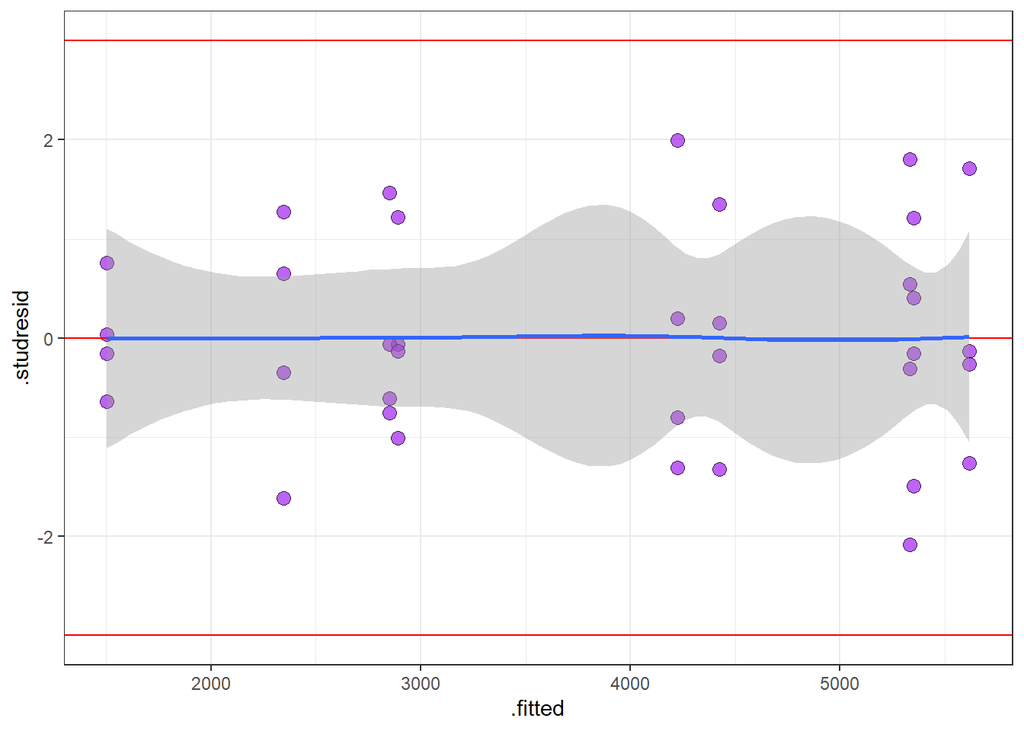

```r
ggplot(crd_resid, aes(x= .fitted,
                      y= .studresid)) +
  geom_point(shape = 21,
             fill= "purple",
             size= 3,
             alpha= 0.7) +
  geom_hline(yintercept = c(-3,0,3), color = "red") +
  geom_smooth() +
  theme_bw()
```

The assumption of residual independence is satisfies as there are no patterns observed. Additionally, the smooth line sits on the the zero of the y axis and the shaded areas are around the zero mark too.

## Residual variance homogeneity

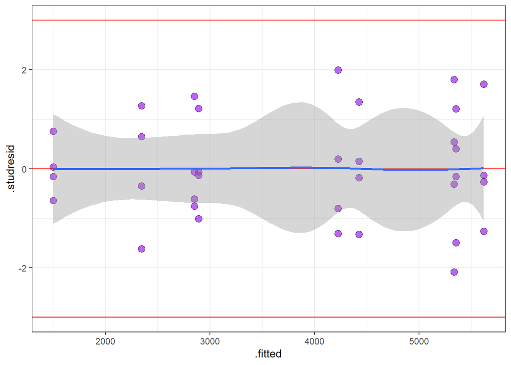

```r
ggplot(crd_resid, aes(x= .fitted,
                      y= .studresid)) +
  geom_point(shape = 21,
             fill= "purple",
             size= 3,
             alpha= 0.7) +
  geom_hline(yintercept = c(-3,0,3), color = "red") +
  geom_smooth() +
  theme_bw()
```

The residuals variance are homogeneous as the spread are uniform across the plot. There is no distinct pattern different from other parts of the plot. There is no heteroscedasticity

## Residual normality

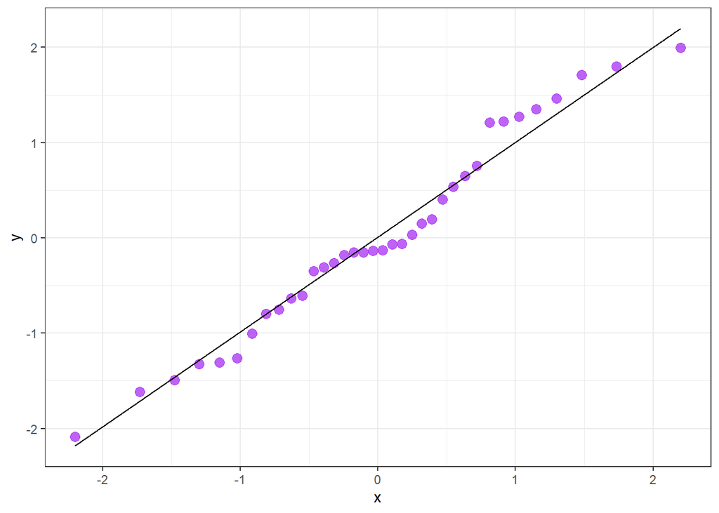

```r
ggplot(crd_resid, aes(sample = .studresid)) +
         stat_qq(color= "purple",
                 size= 3,
                 alpha= 0.7) +
         stat_qq_line() +
  theme_bw()
```

The qq-plot shows that some points are slightly deviated from the line, especially in the middle. It is not on the extreme end, so can be accepted.

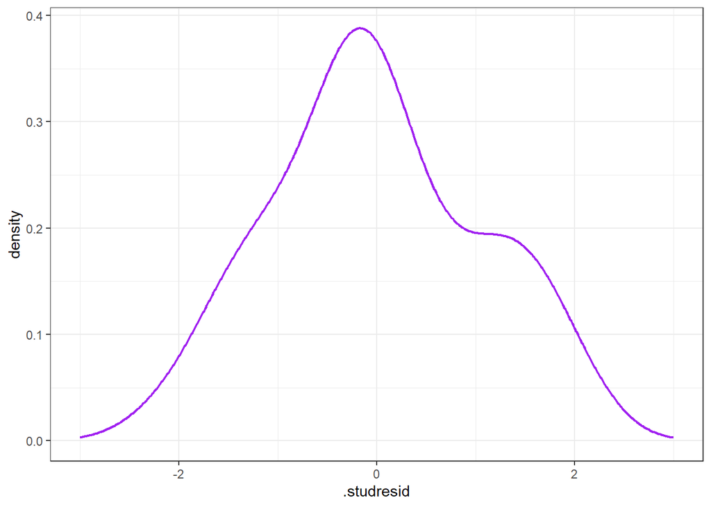

```r
ggplot(crd_resid, aes(x= .studresid)) +
  geom_density(color= "purple",
               linewidth= 0.8) +
  scale_x_continuous(breaks = c(-2,0,2), limits = c(-3,3)) +
  theme_bw()
```

The density plot looks like it has two peaks with the main peak close to the mean. To confirm if the rule of normal distribution is met, more tests on the normal distribution and spread of the residuals are carried out below.

```r
# Shapiro-Wilk Test
shapiro.test(residuals(crd_mod)) # If p < 0.05, residuals significantly deviate from normality
```

```
    Shapiro-Wilk normality test

data:  residuals(crd_mod)
W = 0.96886, p-value = 0.3952
```

```r
# Breusch-Pagan Test
bptest(crd_mod)  # If p < 0.05, heteroscedasticity is present
```

```
    studentized Breusch-Pagan test

data:  crd_mod
BP = 5.6107, df = 8, p-value = 0.6908
```

```r
# Non-Constant Variance Test
ncvTest(crd_mod)  # If p > 0.05, no significant heteroscedasticity detected
```

```
Non-constant Variance Score Test
Variance formula: ~ fitted.values
Chisquare = 1.402714, Df = 1, p = 0.23627
```

```r
# White’s Test for Non-Linear Heteroscedasticity
bptest(crd_mod, ~ fitted(crd_mod) +
         I(fitted(crd_mod)^2))  # p > 0.05 means no evidence of heteroscedasticity.
```

```
    studentized Breusch-Pagan test

data:  crd_mod
BP = 2.5628, df = 2, p-value = 0.2776
```

From the test results above, all p values were above 0.05, hence the assumption is met for normal distribution and double checked for homoscedasticity

## Outlier detection

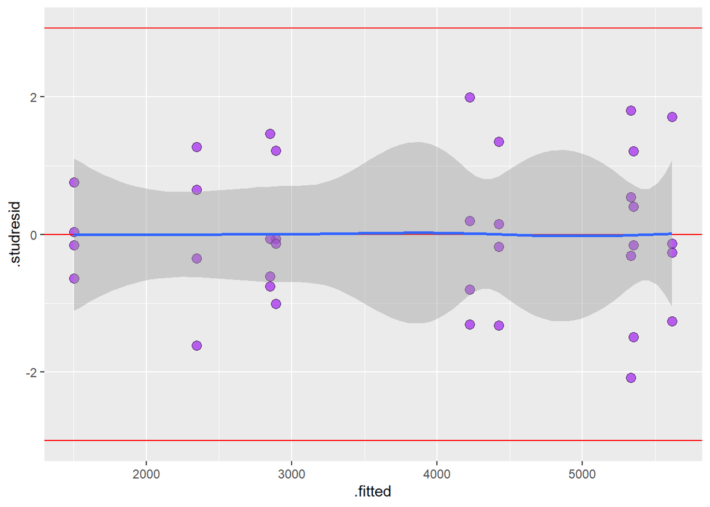

```r
ggplot(crd_resid, aes(x= .fitted,
                      y= .studresid)) +
  geom_point(shape = 21,
             fill= "purple",
             size= 3,
             alpha= 0.7) +
  geom_hline(yintercept = c(-3,0,3), color = "red") +
  geom_smooth()
```

All residuals are within the -3 and 3 range, so there are no outliers. The assumption for outliers is met.

# h) Model means

Use this section to extract model means according to your decision of the ANOVA table effects.

```r
crd_means_n = emmeans(crd_mod, ~nrate_kgha)
#crd_means_n
```

```r
crd_means_k = emmeans(crd_mod, ~krate_kgha)
#crd_means_k
```

# i) Pairwise comparisons

Use this section to perform pair-wise comparison of the means extracted above.

Make sure to reverse the order from high to low, use letters instead of numbers, and no adjustment.

```r
crd_cld_n = cld(crd_means_n,
                reversed = T,
                Letters = letters,
                adjust = "none") %>%
  as_data_frame() %>% # to convert pwc output to dataframe
  mutate(letter = trimws(.group)) # to add an extra column removing space in the letters

crd_cld_n
```

```
# A tibble: 3 × 8
  nrate_kgha emmean    SE    df lower.CL upper.CL .group letter
  <fct>       <dbl> <dbl> <dbl>    <dbl>    <dbl> <chr>  <chr>
1 200         4615.  326.    27    3946.    5283. " a "  a
2 100         3973.  326.    27    3304.    4641. " a "  a
3 0           2926.  326.    27    2258.    3595. "  b"  b
```

```r
crd_cld_k = cld(crd_means_k,
                reversed = T,
                Letters = letters,
                adjust = "none") %>%
  as_data_frame() %>% # to convert pwc output to dataframe
  mutate(letter = trimws(.group)) # to add an extra column removing space in the letters

crd_cld_k
```

```
# A tibble: 3 × 8
  krate_kgha emmean    SE    df lower.CL upper.CL .group letter
  <fct>       <dbl> <dbl> <dbl>    <dbl>    <dbl> <chr>  <chr>
1 60          5037.  326.    27    4369.    5705. " a "  a
2 30          4231.  326.    27    3562.    4899. " a "  a
3 0           2246.  326.    27    1578.    2915. "  b"  b
```

# g) Final plot(s)

Produce final plot(s) to show your results.  
Make sure to include both **raw data** and **statistical model summary (i.e., letter separation)**.

Be mindful of your plot to ensure you are creating it in an intuitive way for your audience in relation to interpreting the letter separation structure you used.

In class, we did not have time to make it publication-ready (e.g., a plot looking professional and ready to be included in a manuscript).

Here, make sure you deliver final plot(s) that is/are publication ready.

Make sure to provide an interpretation for the plot(s) created, including which treatment levels were significantly higher/lower.

**Only plots for main effects for nitrogen and potassium are shown, since there was no significant interactive effect of both treatment factors on wheat yield.**

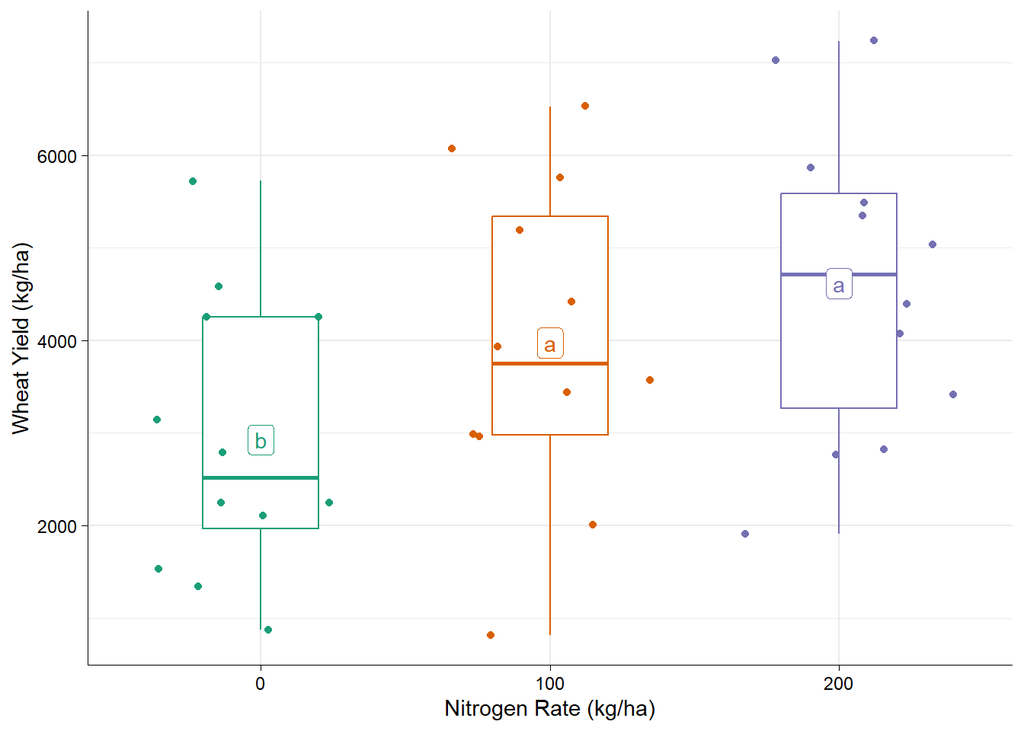

```r
ggplot(data= crd_asw,
               aes(x= nrate_kgha,
                   y= yield_kgha,
                   color= nrate_kgha)) +
  geom_boxplot(width = 0.4) +
  geom_jitter() +
  scale_color_brewer(palette = "Dark2") +
  theme_minimal() +
  geom_label(data = crd_cld_n,
             aes(x= nrate_kgha,
                 y= emmean,
                 label = letter)) +
  theme(legend.position = "none",
        axis.line = element_line(linewidth = 0.3),
        axis.text = element_text(size= 9,
                                 color = "black"),
        axis.ticks = element_line(linewidth = 0.3),
        axis.title = element_text(hjust = 0.5)) +
  labs(x= "Nitrogen Rate (kg/ha)",
       y= "Wheat Yield (kg/ha)")
```

```r
ggsave("nplot.png", path = "../output/")
```

As seen in the figure above, increasing nitrogen rate from 0 kg/ha to 100 kg/ha significantly increased wheat yield. However, increasing nitrogen rate up to 200 kg/ha did not result in additional increase in yield. Hence, 100 kg/ha of nitrogen is recommended to maximize wheat yield.

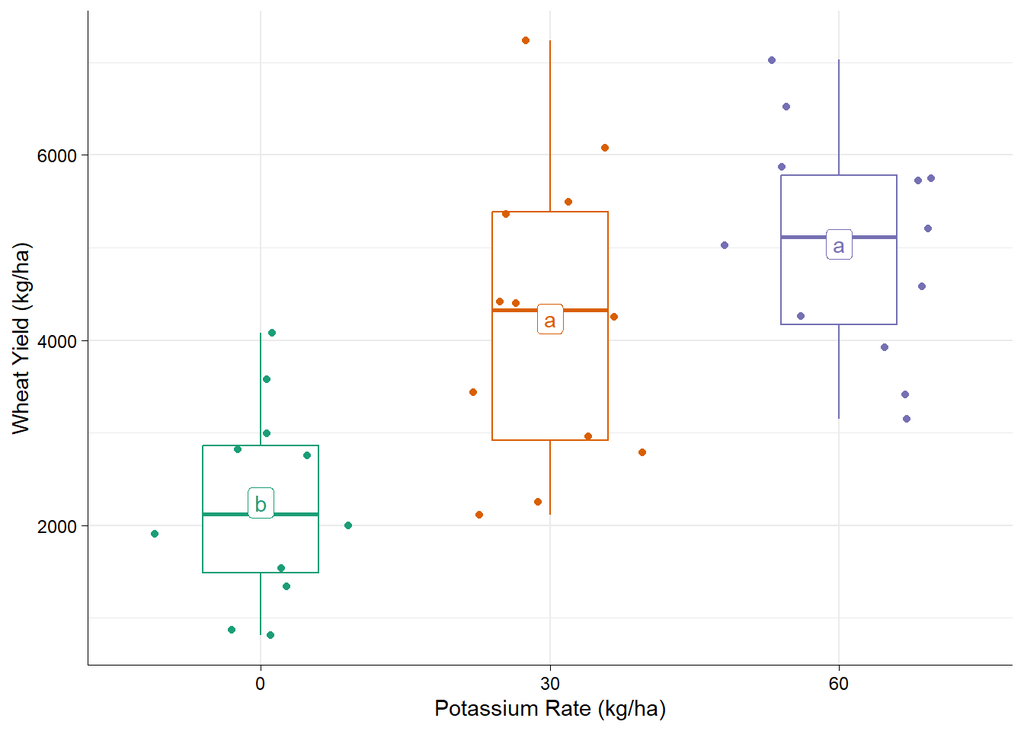

```r
ggplot(data= crd_asw,
               aes(x= krate_kgha,
                   y= yield_kgha,
                   color= krate_kgha)) +
  geom_boxplot(width = 0.4) +
  geom_jitter() +
  scale_color_brewer(palette = "Dark2") +
  theme_minimal() +
  geom_label(data = crd_cld_k,
             aes(x= krate_kgha,
                 y= emmean,
                 label = letter)) +
  theme(legend.position = "none",
        axis.line = element_line(linewidth = 0.3),
        axis.text = element_text(size= 9,
                                 color = "black"),
        axis.ticks = element_line(linewidth = 0.3),
        axis.title = element_text(hjust = 0.5)) +
  labs(x= "Potassium Rate (kg/ha)",
       y= "Wheat Yield (kg/ha)")
```

```r
ggsave("kplot.png", path = "../output/")
```

Potassium rates of 30 and 60 kg/ha resulted in the highest values of wheat yield, and there was no statistical difference between these two potassium rates. To maximize yield, a 30 kg/ha potassium rate is recommended.

# Submitting your work

Once you have developed all the code and answers, make sure to Render this quarto file.

**Notes on rendering**:

- Make sure to render your work and inspect how the final html look like.
- If it does not look professional for whatever reason, then fix the issue, re-render it, recheck.
- Only send me your work once your html file looks professional.
  - **DO NOT** delete the file’s heading levels (# and ##). They set up the proper heading 1 and 2 levels, and I use them to guide my grading.
  - If a given chunk is also outputting warnings or messages, inhibit this behavior by changing the chunk options `message` and `warning` to `FALSE` (I’ll demo this in a moment).
  - If, after rendered, 2 lines of text are connected and you wish to “break line” between them, add 2 extra spaces after the first one (I’lld demo this in a moment).

After rendering, an .html file will be created on your `code` folder.

Rename this file to `Assignment-03-crd-LASTNAME.html`.

For ex., mine would be `Assignment-03-crd-Bastos.html`.

Submit your work by uploading the **html** file to **eLC Assigment #3 - CRD** by Feb 3rd 11:59 pm.